# SIBER Analysis of Coral Physiology

Peter Flood and Serena Hackerott

2/8/2024

# Setup

### Load Packages

```r
##Install Packages if Needed
if (!require("ggplot2")) install.packages("ggplot2")
if (!require("cowplot")) install.packages("cowplot")
if (!require("SIBER")) install.packages("SIBER")
if (!require("vegan")) install.packages("vegan")
if (!require("tidyverse")) install.packages("tidyverse")


##Load Packages
library(ggplot2) #Required for ggplots
library(cowplot) #Required for plotting panel figures
library(SIBER) #Required for generating physiological ellipses and percent overlap calculations
library(vegan) #Required for NMDS
library(Hmisc) #Required for correlations
library(corrplot) #Required for correlation plot
library(tidyverse) #Required for data manipulation
```

# Sample Data and Metadata

### Load and Organize Data

```r
##Load Data
#Note: Physiological metrics calculated in 02_PhysiologyMetrics.R file
Phys<-read.csv("Outputs/CoralData.csv", header=TRUE)

##Set factor variables
Phys$TimeP<-factor(Phys$TimeP, levels=c("TP1", "TP2", "TP3", "TP4"))
Phys$Site<-factor(Phys$Site, levels=c("KL", "SS"))
Phys$Genotype<-factor(Phys$Genotype, levels=c("AC8", "AC10", "AC12"))
Phys$Orig<-factor(Phys$Orig, levels=c("N", "T"))
Phys$Origin<-factor(Phys$Origin, levels=c("Native", "Transplant"))
Phys$Site.Orig<-factor(Phys$Site.Orig, levels=c("KL.N", "KL.T", "SS.N", "SS.T"))
```

### Check Correlation

```r
##Remove NA's
names(Phys)
```

```
##  [1] "ID"              "RandN"           "TimeP"           "Site"
##  [5] "Genotype"        "Orig"            "Origin"          "Set"
##  [9] "Site.Orig"       "SA_cm2"          "TP_ug.cm2_C"     "TP_ug.cm2_S"
## [13] "AFDW_mg.cm2_C"   "AFDW_mg.cm2_S"   "AFDW_mg.cm2_S.C" "Chl_ug.cm2"
```

```r
Phys.rm<-na.omit(Phys)

##Log +1 transform
Phys.log<-Phys.rm
Phys.log[,-c(1:10)]<-log(Phys.rm[,-c(1:10)]+1)

Phys.corr<-rcorr(as.matrix(Phys.log[,-c(1:10)]), type="pearson")
Phys.corr
```

```
##                 TP_ug.cm2_C TP_ug.cm2_S AFDW_mg.cm2_C AFDW_mg.cm2_S
## TP_ug.cm2_C            1.00        0.56          0.55          0.48
## TP_ug.cm2_S            0.56        1.00          0.37          0.41
## AFDW_mg.cm2_C          0.55        0.37          1.00          0.37
## AFDW_mg.cm2_S          0.48        0.41          0.37          1.00
## AFDW_mg.cm2_S.C        0.03        0.08         -0.49          0.60
## Chl_ug.cm2             0.37        0.16          0.33          0.50
##                 AFDW_mg.cm2_S.C Chl_ug.cm2
## TP_ug.cm2_C                0.03       0.37
## TP_ug.cm2_S                0.08       0.16
## AFDW_mg.cm2_C             -0.49       0.33
## AFDW_mg.cm2_S              0.60       0.50
## AFDW_mg.cm2_S.C            1.00       0.20
## Chl_ug.cm2                 0.20       1.00
##
## n= 190
##
##
## P
##                 TP_ug.cm2_C TP_ug.cm2_S AFDW_mg.cm2_C AFDW_mg.cm2_S
## TP_ug.cm2_C                 0.0000      0.0000        0.0000
## TP_ug.cm2_S     0.0000                  0.0000        0.0000
## AFDW_mg.cm2_C   0.0000      0.0000                    0.0000
## AFDW_mg.cm2_S   0.0000      0.0000      0.0000
## AFDW_mg.cm2_S.C 0.6401      0.2762      0.0000        0.0000
## Chl_ug.cm2      0.0000      0.0248      0.0000        0.0000
##                 AFDW_mg.cm2_S.C Chl_ug.cm2
## TP_ug.cm2_C     0.6401          0.0000
## TP_ug.cm2_S     0.2762          0.0248
## AFDW_mg.cm2_C   0.0000          0.0000
## AFDW_mg.cm2_S   0.0000          0.0000
## AFDW_mg.cm2_S.C                 0.0049
## Chl_ug.cm2      0.0049
```

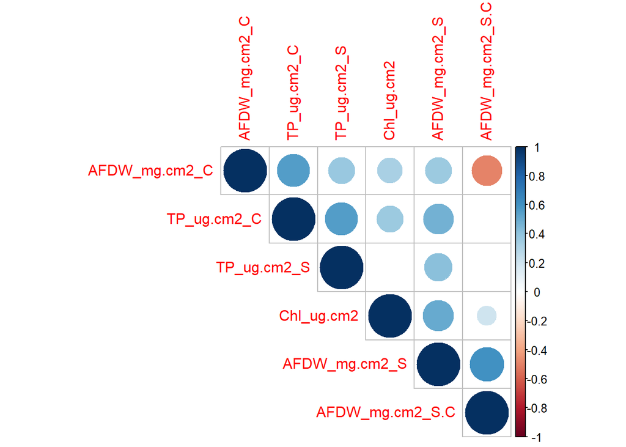

```r
diag(Phys.corr$P)<-0

corrplot(Phys.corr$r, type="upper", order="hclust",
         p.mat = Phys.corr$P, sig.level = 0.01, insig = "blank")
```

# SIBER Ellipses

## SIBER Prep

### Ordination

```r
#SIBER runs on a two dimensional data set
#So, first we need to reduce the dimensionality of the physiology data
#We're going to do this via Non-Metric Multidimensional Scaling (NMDS)

#Select only the physiology columns (numbers only without covariates) to put into the NMDS
phys.log.num <- Phys.log %>% select(SA_cm2:Chl_ug.cm2)

#Run NMDS
phys.nmds <- metaMDS(phys.log.num, distance = "bray", k = 2, autotransform = F)
```

```
## *** Best solution was not repeated -- monoMDS stopping criteria:
##     19: no. of iterations >= maxit
##      1: stress ratio > sratmax
```

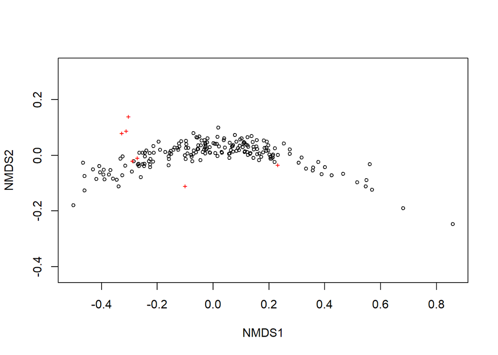

```r
#Quick plot of NMDS output
ordiplot(phys.nmds)
```

### Data Prep for SIBER

```r
#Prepare data to be input into SIBER
phys.siber.input <- phys.nmds$points %>% #extract 2-D physiology axes from NMDS
  bind_cols(#add back covariates from original phys data
    select(Phys.log, ID:Site.Orig) #select those covariate columns
  ) %>%
  #SIBER object needs four specific columns
  #iso1, iso2, group, and community
  #Need to manipulate the data to match that format
  #create  group variable that combines site, genotype and origin
  unite("group", c(Site, Genotype, Orig), sep = "_") %>%
  #rename variables to match names for SIBER
  rename(community = TimeP, iso1 = MDS1, iso2 = MDS2) %>%
  #retain only columns for SIBER
  select(iso1, iso2, group, community)
```

### Run SIBER

Grouping by each genotype at each site, timepoint, and from each origin

```r
# create SIBER object
phys.siber.object <- createSiberObject(phys.siber.input)

# sample sizes by group
phys.siber.object[["sample.sizes"]]
```

```
##     KL_AC10_N KL_AC10_T KL_AC12_N KL_AC12_T KL_AC8_N KL_AC8_T SS_AC10_N
## TP1         4         4         4         4        4        4         4
## TP2         4         4         4         4        4        4         4
## TP3         4         4         4         4        4        4         4
## TP4         4         4         4         4        4        3         4
##     SS_AC10_T SS_AC12_N SS_AC12_T SS_AC8_N SS_AC8_T
## TP1         4         4         4        4        4
## TP2         4         4         4        4        4
## TP3         4         4         4        4        4
## TP4         4         4         4        4        3
```

```r
# visualize SIBER groups

# Create lists of plotting arguments to be passed onwards to each
# of the three plotting functions.
community.hulls.args <- list(col = 1, lty = 1, lwd = 1)
group.ellipses.args  <- list(n = 100, p.interval = 0.95,
                             lty = 1, lwd = 2)
group.hull.args      <- list(lty = 2, col = "grey20")


# ellipses and group.hulls are set to TRUE or T for short to force
# their plotting.
par(mfrow=c(1,1))
plotSiberObject(phys.siber.object,
                  ax.pad = 2,
                  hulls = F, community.hulls.args,
                  ellipses = T, group.ellipses.args,
                  group.hulls = T, group.hull.args,
                  bty = "L",
                  iso.order = c(1,2),
                  xlab = expression({delta}^13*C~'permille'),
                  ylab = expression({delta}^15*N~'permille')
                  )

# You can add more ellipses by directly calling plot.group.ellipses()
# Add an additional p.interval % prediction ellilpse
plotGroupEllipses(phys.siber.object, n = 100, p.interval = 0.95,
                    lty = 1, lwd = 2)

# or you can add the XX% confidence interval around the bivariate means
# by specifying ci.mean = T along with whatever p.interval you want.
plotGroupEllipses(phys.siber.object, n = 100, p.interval = 0.95,
                  ci.mean = T, lty = 1, lwd = 2)

# Calculate sumamry statistics for each group: TA, SEA and SEAc
group.ML <- groupMetricsML(phys.siber.object)
print(group.ML)
```

```
##      TP1.KL_AC10_N TP1.KL_AC10_T TP1.KL_AC12_N TP1.KL_AC12_T TP1.KL_AC8_N
## TA     0.005504355   0.002923558   0.002106524  0.0008199082   0.01845368
## SEA    0.005987678   0.003838279   0.002587096  0.0010546224   0.02191789
## SEAc   0.008981517   0.005757418   0.003880643  0.0015819336   0.03287683
##      TP1.KL_AC8_T TP1.SS_AC10_N TP1.SS_AC10_T TP1.SS_AC12_N TP1.SS_AC12_T
## TA    0.002350455   0.004027072   0.003399343   0.005027270    0.01472161
## SEA   0.003004596   0.004872269   0.004852745   0.006627584    0.01784532
## SEAc  0.004506895   0.007308403   0.007279117   0.009941376    0.02676798
##      TP1.SS_AC8_N TP1.SS_AC8_T TP2.KL_AC10_N TP2.KL_AC10_T TP2.KL_AC12_N
## TA    0.003613379  0.002052001   0.002092216   0.001022511   0.003211730
## SEA   0.004315960  0.002892317   0.002210969   0.001146911   0.003625876
## SEAc  0.006473940  0.004338476   0.003316453   0.001720366   0.005438815
##      TP2.KL_AC12_T TP2.KL_AC8_N TP2.KL_AC8_T TP2.SS_AC10_N TP2.SS_AC10_T
## TA     0.002674716 0.0009718381  0.007220569   0.001689669  0.0009759943
## SEA    0.003679476 0.0012844830  0.009292843   0.002114921  0.0011999164
## SEAc   0.005519215 0.0019267244  0.013939264   0.003172382  0.0017998747
##      TP2.SS_AC12_N TP2.SS_AC12_T TP2.SS_AC8_N TP2.SS_AC8_T TP3.KL_AC10_N
## TA    0.0008530896    0.01537463 0.0007946927  0.009126735  0.0007920212
## SEA   0.0011375927    0.02198818 0.0009640284  0.012275283  0.0008383781
## SEAc  0.0017063891    0.03298227 0.0014460427  0.018412924  0.0012575671
##      TP3.KL_AC10_T TP3.KL_AC12_N TP3.KL_AC12_T TP3.KL_AC8_N TP3.KL_AC8_T
## TA     0.001248106   0.000768032    0.01494732  0.002313531  0.003000569
## SEA    0.001341748   0.000975620    0.01780641  0.002941501  0.003168920
## SEAc   0.002012622   0.001463430    0.02670962  0.004412252  0.004753381
##      TP3.SS_AC10_N TP3.SS_AC10_T TP3.SS_AC12_N TP3.SS_AC12_T TP3.SS_AC8_N
## TA     0.005565975  0.0006307714   0.001525290   0.004772648  0.003267303
## SEA    0.006732685  0.0007215893   0.001818342   0.006464417  0.003987008
## SEAc   0.010099027  0.0010823839   0.002727513   0.009696626  0.005980513
##      TP3.SS_AC8_T TP4.KL_AC10_N TP4.KL_AC10_T TP4.KL_AC12_N TP4.KL_AC12_T
## TA    0.001251374   0.002902957    0.01169435    0.01193889   0.002662488
## SEA   0.001627207   0.003728787    0.01466243    0.01652923   0.003503348
## SEAc  0.002440810   0.005593180    0.02199364    0.02479385   0.005255021
##      TP4.KL_AC8_N TP4.KL_AC8_T TP4.SS_AC10_N TP4.SS_AC10_T TP4.SS_AC12_N
## TA     0.01528847  0.006689904   0.004960854   0.003407949    0.06369911
## SEA    0.02079014  0.012134144   0.006303492   0.003706203    0.08141168
## SEAc   0.03118521  0.024268288   0.009455238   0.005559305    0.12211752
##      TP4.SS_AC12_T TP4.SS_AC8_N TP4.SS_AC8_T
## TA      0.01773280   0.04282786  0.002512805
## SEA     0.02050783   0.05695024  0.004557723
## SEAc    0.03076174   0.08542535  0.009115447
```

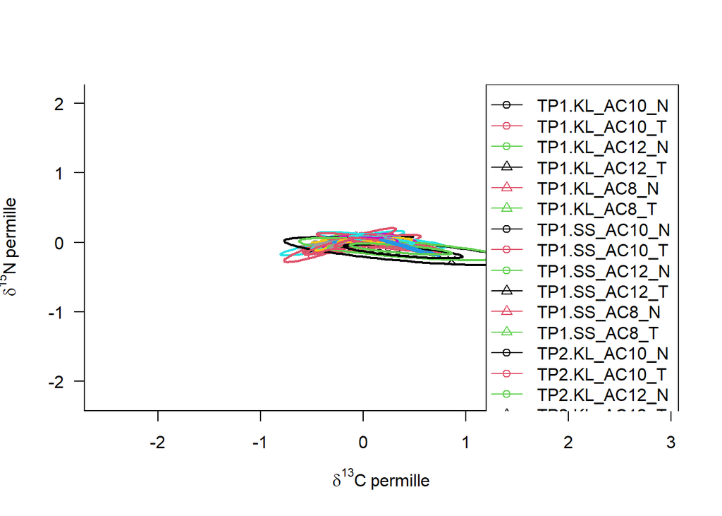

```r
legend("topright", colnames(group.ML),
       pch = c(1,1,1,2,2,2), col = c(1:3, 1:3), lty = 1)
```

```r
#set up the model parameters
# options for running jags
parms <- list()
parms$n.iter <- 2 * 10^6   # number of iterations to run the model for
parms$n.burnin <- 1 * 10^4 # discard the first set of values
parms$n.thin <- 100     # thin the posterior by this many
parms$n.chains <- 2        # run this many chains
parms$save.output = T
parms$save.dir = getwd()

# define the priors
priors <- list()
priors$R <- 1 * diag(2)
priors$k <- 2
priors$tau.mu <- 1.0E-3

#SIBER generates a lot of jags output
#changing working directory to where that output should go
setwd("~/Bonaire_memory/Outputs/SIBER")
#knitr::opts_knit$set(root.dir = "~/Bonaire_memory/Outputs/SIBER")

# fit the ellipses which uses an Inverse Wishart prior
# on the covariance matrix Sigma, and a vague normal prior on the
# means. Fitting is via the JAGS method.
phys.ellipses.posterior <- siberMVN(phys.siber.object, parms, priors)
#calculate posterior estimates of ellipses for all groups
SEA.B<-siberEllipses(phys.ellipses.posterior)
#set column names for SEA.B
colnames(SEA.B)<-names(phys.ellipses.posterior)
```

# Ellipse Overlap

### Calculate Percent Overlap

Do native and transplant fragments become more similar over time within each genotype at each site

######KL_AC10

Native and transplant overlap at time 1

```r
overlap.kl.ac10.tp1.n.t <- maxLikOverlap("TP1.KL_AC10_N", "TP1.KL_AC10_T", phys.siber.object,
                                   p = 0.95, n = 360)
p.overlap.kl.ac10.tp1.n.t <- as.numeric(overlap.kl.ac10.tp1.n.t["overlap"] /
                            (overlap.kl.ac10.tp1.n.t["area.1"]+
                               overlap.kl.ac10.tp1.n.t["area.2"]-
                               overlap.kl.ac10.tp1.n.t["overlap"])) #overlap is shared area between area.1 and area.2, if we don't subtract the overlap it would get counted twice into the total area of area.1 union area.2
```

Native and transplant overlap at time 2

```r
overlap.kl.ac10.tp2.n.t <- maxLikOverlap("TP2.KL_AC10_N", "TP2.KL_AC10_T", phys.siber.object,
                                   p = 0.95, n = 360)
p.overlap.kl.ac10.tp2.n.t <- as.numeric(overlap.kl.ac10.tp2.n.t["overlap"] /
                            (overlap.kl.ac10.tp2.n.t["area.1"]+
                               overlap.kl.ac10.tp2.n.t["area.2"]-
                               overlap.kl.ac10.tp2.n.t["overlap"]))
```

Native and transplant overlap at time 3

```r
overlap.kl.ac10.tp3.n.t <- maxLikOverlap("TP3.KL_AC10_N", "TP3.KL_AC10_T", phys.siber.object,
                                   p = 0.95, n = 360)
p.overlap.kl.ac10.tp3.n.t <- as.numeric(overlap.kl.ac10.tp3.n.t["overlap"] /
                            (overlap.kl.ac10.tp3.n.t["area.1"]+
                               overlap.kl.ac10.tp3.n.t["area.2"]-
                               overlap.kl.ac10.tp3.n.t["overlap"]))
```

Native and transplant overlap at time 4

```r
overlap.kl.ac10.tp4.n.t <- maxLikOverlap("TP4.KL_AC10_N", "TP4.KL_AC10_T", phys.siber.object,
                                   p = 0.95, n = 360)
p.overlap.kl.ac10.tp4.n.t <- as.numeric(overlap.kl.ac10.tp4.n.t["overlap"] /
                            (overlap.kl.ac10.tp4.n.t["area.1"]+
                               overlap.kl.ac10.tp4.n.t["area.2"]-
                               overlap.kl.ac10.tp4.n.t["overlap"]))
```

######KL_AC8

Native and transplant overlap at time 1

```r
overlap.kl.ac8.tp1.n.t <- maxLikOverlap("TP1.KL_AC8_N", "TP1.KL_AC8_T", phys.siber.object,
                                   p = 0.95, n = 360)
p.overlap.kl.ac8.tp1.n.t <- as.numeric(overlap.kl.ac8.tp1.n.t["overlap"] /
                            (overlap.kl.ac8.tp1.n.t["area.1"]+
                               overlap.kl.ac8.tp1.n.t["area.2"]-
                               overlap.kl.ac8.tp1.n.t["overlap"])) #overlap is shared area between area.1 and area.2, if we don't subtract the overlap it would get counted twice into the total area of area.1 union area.2
```

Native and transplant overlap at time 2

```r
overlap.kl.ac8.tp2.n.t <- maxLikOverlap("TP2.KL_AC8_N", "TP2.KL_AC8_T", phys.siber.object,
                                   p = 0.95, n = 360)
p.overlap.kl.ac8.tp2.n.t <- as.numeric(overlap.kl.ac8.tp2.n.t["overlap"] /
                            (overlap.kl.ac8.tp2.n.t["area.1"]+
                               overlap.kl.ac8.tp2.n.t["area.2"]-
                               overlap.kl.ac8.tp2.n.t["overlap"]))
```

Native and transplant overlap at time 3

```r
overlap.kl.ac8.tp3.n.t <- maxLikOverlap("TP3.KL_AC8_N", "TP3.KL_AC8_T", phys.siber.object,
                                   p = 0.95, n = 360)
p.overlap.kl.ac8.tp3.n.t <- as.numeric(overlap.kl.ac8.tp3.n.t["overlap"] /
                            (overlap.kl.ac8.tp3.n.t["area.1"]+
                               overlap.kl.ac8.tp3.n.t["area.2"]-
                               overlap.kl.ac8.tp3.n.t["overlap"]))
```

Native and transplant overlap at time 4

```r
overlap.kl.ac8.tp4.n.t <- maxLikOverlap("TP4.KL_AC8_N", "TP4.KL_AC8_T", phys.siber.object,
                                   p = 0.95, n = 360)
p.overlap.kl.ac8.tp4.n.t <- as.numeric(overlap.kl.ac8.tp4.n.t["overlap"] /
                            (overlap.kl.ac8.tp4.n.t["area.1"]+
                               overlap.kl.ac8.tp4.n.t["area.2"]-
                               overlap.kl.ac8.tp4.n.t["overlap"]))
```

######KL_AC12

Native and transplant overlap at time 1

```r
overlap.kl.ac12.tp1.n.t <- maxLikOverlap("TP1.KL_AC12_N", "TP1.KL_AC12_T", phys.siber.object,
                                   p = 0.95, n = 360)
p.overlap.kl.ac12.tp1.n.t <- as.numeric(overlap.kl.ac12.tp1.n.t["overlap"] /
                            (overlap.kl.ac12.tp1.n.t["area.1"]+
                               overlap.kl.ac12.tp1.n.t["area.2"]-
                               overlap.kl.ac12.tp1.n.t["overlap"])) #overlap is shared area between area.1 and area.2, if we don't subtract the overlap it would get counted twice into the total area of area.1 union area.2
```

Native and transplant overlap at time 2

```r
overlap.kl.ac12.tp2.n.t <- maxLikOverlap("TP2.KL_AC12_N", "TP2.KL_AC12_T", phys.siber.object,
                                   p = 0.95, n = 360)
p.overlap.kl.ac12.tp2.n.t <- as.numeric(overlap.kl.ac12.tp2.n.t["overlap"] /
                            (overlap.kl.ac12.tp2.n.t["area.1"]+
                               overlap.kl.ac12.tp2.n.t["area.2"]-
                               overlap.kl.ac12.tp2.n.t["overlap"]))
```

Native and transplant overlap at time 3

```r
overlap.kl.ac12.tp3.n.t <- maxLikOverlap("TP3.KL_AC12_N", "TP3.KL_AC12_T", phys.siber.object,
                                   p = 0.95, n = 360)
p.overlap.kl.ac12.tp3.n.t <- as.numeric(overlap.kl.ac12.tp3.n.t["overlap"] /
                            (overlap.kl.ac12.tp3.n.t["area.1"]+
                               overlap.kl.ac12.tp3.n.t["area.2"]-
                               overlap.kl.ac12.tp3.n.t["overlap"]))
```

Native and transplant overlap at time 4

```r
overlap.kl.ac12.tp4.n.t <- maxLikOverlap("TP4.KL_AC12_N", "TP4.KL_AC12_T", phys.siber.object,
                                   p = 0.95, n = 360)
p.overlap.kl.ac12.tp4.n.t <- as.numeric(overlap.kl.ac12.tp4.n.t["overlap"] /
                            (overlap.kl.ac12.tp4.n.t["area.1"]+
                               overlap.kl.ac12.tp4.n.t["area.2"]-
                               overlap.kl.ac12.tp4.n.t["overlap"]))
```

######SS_AC10

Native and transplant overlap at time 1

```r
overlap.ss.ac10.tp1.n.t <- maxLikOverlap("TP1.SS_AC10_N", "TP1.SS_AC10_T", phys.siber.object,
                                   p = 0.95, n = 360)
p.overlap.ss.ac10.tp1.n.t <- as.numeric(overlap.ss.ac10.tp1.n.t["overlap"] /
                            (overlap.ss.ac10.tp1.n.t["area.1"]+
                               overlap.ss.ac10.tp1.n.t["area.2"]-
                               overlap.ss.ac10.tp1.n.t["overlap"])) #overlap is shared area between area.1 and area.2, if we don't subtract the overlap it would get counted twice into the total area of area.1 union area.2
```

Native and transplant overlap at time 2

```r
overlap.ss.ac10.tp2.n.t <- maxLikOverlap("TP2.SS_AC10_N", "TP2.SS_AC10_T", phys.siber.object,
                                   p = 0.95, n = 360)
p.overlap.ss.ac10.tp2.n.t <- as.numeric(overlap.ss.ac10.tp2.n.t["overlap"] /
                            (overlap.ss.ac10.tp2.n.t["area.1"]+
                               overlap.ss.ac10.tp2.n.t["area.2"]-
                               overlap.ss.ac10.tp2.n.t["overlap"]))
```

Native and transplant overlap at time 3

```r
overlap.ss.ac10.tp3.n.t <- maxLikOverlap("TP3.SS_AC10_N", "TP3.SS_AC10_T", phys.siber.object,
                                   p = 0.95, n = 360)
p.overlap.ss.ac10.tp3.n.t <- as.numeric(overlap.ss.ac10.tp3.n.t["overlap"] /
                            (overlap.ss.ac10.tp3.n.t["area.1"]+
                               overlap.ss.ac10.tp3.n.t["area.2"]-
                               overlap.ss.ac10.tp3.n.t["overlap"]))
```

Native and transplant overlap at time 4

```r
overlap.ss.ac10.tp4.n.t <- maxLikOverlap("TP4.SS_AC10_N", "TP4.SS_AC10_T", phys.siber.object,
                                   p = 0.95, n = 360)
p.overlap.ss.ac10.tp4.n.t <- as.numeric(overlap.ss.ac10.tp4.n.t["overlap"] /
                            (overlap.ss.ac10.tp4.n.t["area.1"]+
                               overlap.ss.ac10.tp4.n.t["area.2"]-
                               overlap.ss.ac10.tp4.n.t["overlap"]))
```

######SS_AC8

Native and transplant overlap at time 1

```r
overlap.ss.ac8.tp1.n.t <- maxLikOverlap("TP1.SS_AC8_N", "TP1.SS_AC8_T", phys.siber.object,
                                   p = 0.95, n = 360)
p.overlap.ss.ac8.tp1.n.t <- as.numeric(overlap.ss.ac8.tp1.n.t["overlap"] /
                            (overlap.ss.ac8.tp1.n.t["area.1"]+
                               overlap.ss.ac8.tp1.n.t["area.2"]-
                               overlap.ss.ac8.tp1.n.t["overlap"])) #overlap is shared area between area.1 and area.2, if we don't subtract the overlap it would get counted twice into the total area of area.1 union area.2
```

Native and transplant overlap at time 2

```r
overlap.ss.ac8.tp2.n.t <- maxLikOverlap("TP2.SS_AC8_N", "TP2.SS_AC8_T", phys.siber.object,
                                   p = 0.95, n = 360)
p.overlap.ss.ac8.tp2.n.t <- as.numeric(overlap.ss.ac8.tp2.n.t["overlap"] /
                            (overlap.ss.ac8.tp2.n.t["area.1"]+
                               overlap.ss.ac8.tp2.n.t["area.2"]-
                               overlap.ss.ac8.tp2.n.t["overlap"]))
```

Native and transplant overlap at time 3

```r
overlap.ss.ac8.tp3.n.t <- maxLikOverlap("TP3.SS_AC8_N", "TP3.SS_AC8_T", phys.siber.object,
                                   p = 0.95, n = 360)
p.overlap.ss.ac8.tp3.n.t <- as.numeric(overlap.ss.ac8.tp3.n.t["overlap"] /
                            (overlap.ss.ac8.tp3.n.t["area.1"]+
                               overlap.ss.ac8.tp3.n.t["area.2"]-
                               overlap.ss.ac8.tp3.n.t["overlap"]))
```

Native and transplant overlap at time 4

```r
overlap.ss.ac8.tp4.n.t <- maxLikOverlap("TP4.SS_AC8_N", "TP4.SS_AC8_T", phys.siber.object,
                                   p = 0.95, n = 360)
p.overlap.ss.ac8.tp4.n.t <- as.numeric(overlap.ss.ac8.tp4.n.t["overlap"] /
                            (overlap.ss.ac8.tp4.n.t["area.1"]+
                               overlap.ss.ac8.tp4.n.t["area.2"]-
                               overlap.ss.ac8.tp4.n.t["overlap"]))
```

######SS_AC12

Native and transplant overlap at time 1

```r
overlap.ss.ac12.tp1.n.t <- maxLikOverlap("TP1.SS_AC12_N", "TP1.SS_AC12_T", phys.siber.object,
                                   p = 0.95, n = 360)
p.overlap.ss.ac12.tp1.n.t <- as.numeric(overlap.ss.ac12.tp1.n.t["overlap"] /
                            (overlap.ss.ac12.tp1.n.t["area.1"]+
                               overlap.ss.ac12.tp1.n.t["area.2"]-
                               overlap.ss.ac12.tp1.n.t["overlap"])) #overlap is shared area between area.1 and area.2, if we don't subtract the overlap it would get counted twice into the total area of area.1 union area.2
```

Native and transplant overlap at time 2

```r
overlap.ss.ac12.tp2.n.t <- maxLikOverlap("TP2.SS_AC12_N", "TP2.SS_AC12_T", phys.siber.object,
                                   p = 0.95, n = 360)
p.overlap.ss.ac12.tp2.n.t <- as.numeric(overlap.ss.ac12.tp2.n.t["overlap"] /
                            (overlap.ss.ac12.tp2.n.t["area.1"]+
                               overlap.ss.ac12.tp2.n.t["area.2"]-
                               overlap.ss.ac12.tp2.n.t["overlap"]))
```

Native and transplant overlap at time 3

```r
overlap.ss.ac12.tp3.n.t <- maxLikOverlap("TP3.SS_AC12_N", "TP3.SS_AC12_T", phys.siber.object,
                                   p = 0.95, n = 360)
p.overlap.ss.ac12.tp3.n.t <- as.numeric(overlap.ss.ac12.tp3.n.t["overlap"] /
                            (overlap.ss.ac12.tp3.n.t["area.1"]+
                               overlap.ss.ac12.tp3.n.t["area.2"]-
                               overlap.ss.ac12.tp3.n.t["overlap"]))
```

Native and transplant overlap at time 4

```r
overlap.ss.ac12.tp4.n.t <- maxLikOverlap("TP4.SS_AC12_N", "TP4.SS_AC12_T", phys.siber.object,
                                   p = 0.95, n = 360)
p.overlap.ss.ac12.tp4.n.t <- as.numeric(overlap.ss.ac12.tp4.n.t["overlap"] /
                            (overlap.ss.ac12.tp4.n.t["area.1"]+
                               overlap.ss.ac12.tp4.n.t["area.2"]-
                               overlap.ss.ac12.tp4.n.t["overlap"]))
```

### Create Percent Overlap Dataframe

```r
#create vector of all overlaps
p.overlap <- c(
  p.overlap.kl.ac10.tp1.n.t, p.overlap.kl.ac10.tp2.n.t, p.overlap.kl.ac10.tp3.n.t, p.overlap.kl.ac10.tp4.n.t,
  p.overlap.kl.ac8.tp1.n.t, p.overlap.kl.ac8.tp2.n.t, p.overlap.kl.ac8.tp3.n.t, p.overlap.kl.ac8.tp4.n.t,
  p.overlap.kl.ac12.tp1.n.t, p.overlap.kl.ac12.tp2.n.t, p.overlap.kl.ac12.tp3.n.t, p.overlap.kl.ac12.tp4.n.t,
  p.overlap.ss.ac10.tp1.n.t, p.overlap.ss.ac10.tp2.n.t, p.overlap.ss.ac10.tp3.n.t, p.overlap.ss.ac10.tp4.n.t,
  p.overlap.ss.ac8.tp1.n.t, p.overlap.ss.ac8.tp2.n.t, p.overlap.ss.ac8.tp3.n.t, p.overlap.ss.ac8.tp4.n.t,
  p.overlap.ss.ac12.tp1.n.t, p.overlap.ss.ac12.tp2.n.t, p.overlap.ss.ac12.tp3.n.t, p.overlap.ss.ac12.tp4.n.t
)

#create vector of names for all overlaps
p.overlap.names <- c(
  "kl.ac10.tp1.n.t", "kl.ac10.tp2.n.t", "kl.ac10.tp3.n.t", "kl.ac10.tp4.n.t",
  "kl.ac8.tp1.n.t", "kl.ac8.tp2.n.t", "kl.ac8.tp3.n.t", "kl.ac8.tp4.n.t",
  "kl.ac12.tp1.n.t", "kl.ac12.tp2.n.t", "kl.ac12.tp3.n.t", "kl.ac12.tp4.n.t",
  "ss.ac10.tp1.n.t", "ss.ac10.tp2.n.t", "ss.ac10.tp3.n.t", "ss.ac10.tp4.n.t",
  "ss.ac8.tp1.n.t", "ss.ac8.tp2.n.t", "ss.ac8.tp3.n.t", "ss.ac8.tp4.n.t",
  "ss.ac12.tp1.n.t", "ss.ac12.tp2.n.t", "ss.ac12.tp3.n.t", "ss.ac12.tp4.n.t"
)
#bind into one data frame and prep for other uses
p.overlap.df <- bind_cols(p.overlap, p.overlap.names) %>% #bind p.overlap and names together
  rename(p_overlap = "...1", names = "...2") %>% #rename columns
  #separate the names column into its pieces
  separate(names, into = c("Site", "Genotype", "Time Period", "Comparison"), sep = "[//.]") %>%
  #edit contents of the columns we just created to match other tables and figures
  #need to capitalize letters
  mutate(across(c(Site:Comparison), toupper)) %>%
  #create new column that is a numeric time period that represents "End"
  mutate(`Time Period` = case_when(
    `Time Period` == "TP1" ~ 1,
    `Time Period` == "TP2" ~ 2,
    `Time Period` == "TP3" ~ 3,
    `Time Period` == "TP4" ~ 4
  ),
  Comparison = gsub("N", "Native vs Transplant", Comparison))
```

# Figures

## Percent Overlap Through Time

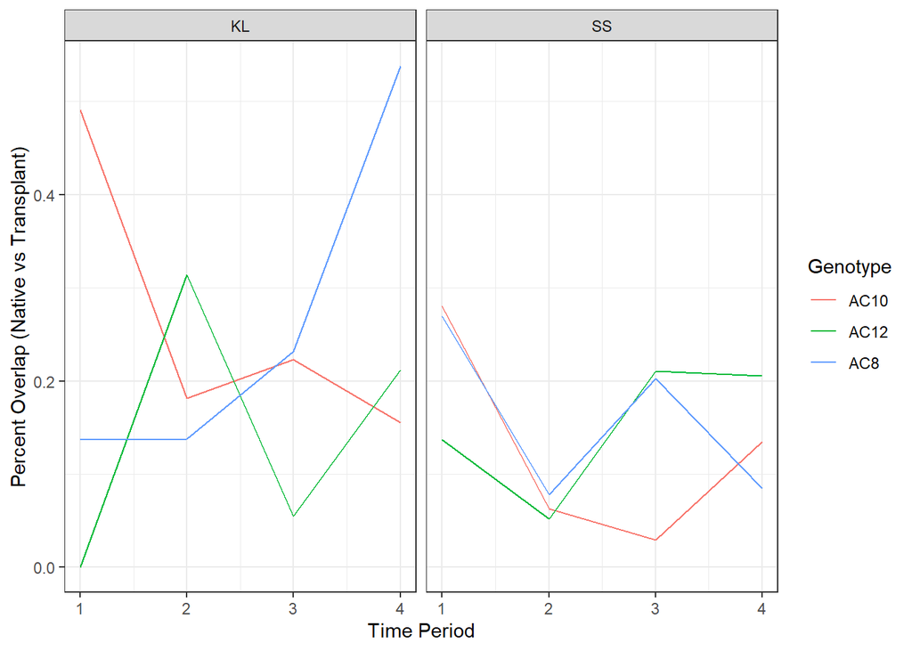

```r
(p.overlap.tp.plot <- ggplot(data = p.overlap.df,
                             aes(x = `Time Period`, y = p.overlap, color = Genotype))+
   geom_line()+
   #geom_boxplot()
   facet_wrap(~Site)+
   #scale_x_continuous(breaks = c(2, 3, 4))+
   labs(y = "Percent Overlap (Native vs Transplant)")+
   theme_bw()
)
```